# Red Wine Quality Data Analysis

# by Thiago Machado

INTRODUCTION

This exploration takes the Red Wine Quality data set and analysis some aspects of it.

This tidy data set contains 1,599 red wines with 11 variables on the chemical properties of the wine. At least 3 wine experts rated the quality of each wine, providing a rating between 0 (very bad) and 10 (very excellent).Some variables are: fixed acidity, residual sugar, density, alcohol and quality.

The first thing to do after a previous analysis of the data is make some questions: What is the main feature of the analisys? What is the secondaries features of the analisys? How they relatad with each other (main and secondaries features)? Which chemical properties influence the quality of red wines?

…

```
## [1] "C:/Users/templ_000/Dropbox/Udacity/Analista de Dados/Projeto4/Projeto"
```

# Univariate Plots Section

```
##        X          fixed.acidity   volatile.acidity  citric.acid
##  Min.   :   1.0   Min.   : 4.60   Min.   :0.1200   Min.   :0.000
##  1st Qu.: 400.5   1st Qu.: 7.10   1st Qu.:0.3900   1st Qu.:0.090
##  Median : 800.0   Median : 7.90   Median :0.5200   Median :0.260
##  Mean   : 800.0   Mean   : 8.32   Mean   :0.5278   Mean   :0.271
##  3rd Qu.:1199.5   3rd Qu.: 9.20   3rd Qu.:0.6400   3rd Qu.:0.420
##  Max.   :1599.0   Max.   :15.90   Max.   :1.5800   Max.   :1.000
##  residual.sugar     chlorides       free.sulfur.dioxide
##  Min.   : 0.900   Min.   :0.01200   Min.   : 1.00
##  1st Qu.: 1.900   1st Qu.:0.07000   1st Qu.: 7.00
##  Median : 2.200   Median :0.07900   Median :14.00
##  Mean   : 2.539   Mean   :0.08747   Mean   :15.87
##  3rd Qu.: 2.600   3rd Qu.:0.09000   3rd Qu.:21.00
##  Max.   :15.500   Max.   :0.61100   Max.   :72.00
##  total.sulfur.dioxide    density             pH          sulphates
##  Min.   :  6.00       Min.   :0.9901   Min.   :2.740   Min.   :0.3300
##  1st Qu.: 22.00       1st Qu.:0.9956   1st Qu.:3.210   1st Qu.:0.5500
##  Median : 38.00       Median :0.9968   Median :3.310   Median :0.6200
##  Mean   : 46.47       Mean   :0.9967   Mean   :3.311   Mean   :0.6581
##  3rd Qu.: 62.00       3rd Qu.:0.9978   3rd Qu.:3.400   3rd Qu.:0.7300
##  Max.   :289.00       Max.   :1.0037   Max.   :4.010   Max.   :2.0000
##     alcohol         quality
##  Min.   : 8.40   Min.   :3.000
##  1st Qu.: 9.50   1st Qu.:5.000
##  Median :10.20   Median :6.000
##  Mean   :10.42   Mean   :5.636
##  3rd Qu.:11.10   3rd Qu.:6.000
##  Max.   :14.90   Max.   :8.000
```

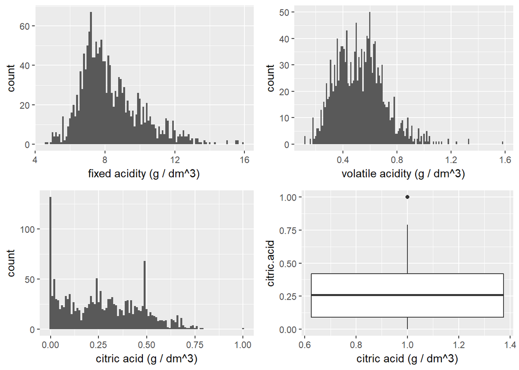

I decided to divide the variables in groups. This is the acids. Like you can see, the first variables has a normal distribution plot. Otherwise, the third one suggests a right skewed behavior, but with some outliers (as you can see in the boxplot plot).

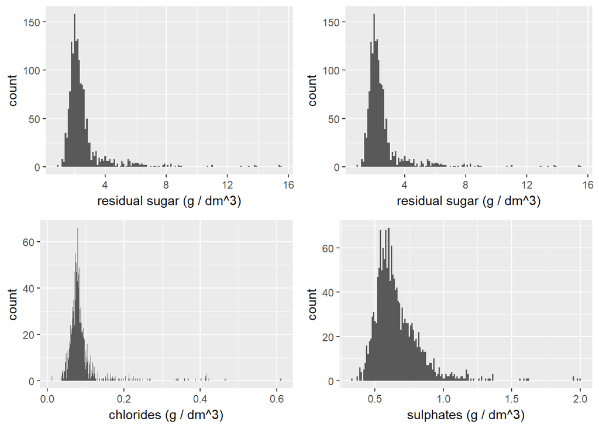

```
##    Min. 1st Qu.  Median    Mean 3rd Qu.    Max.
##   0.900   1.900   2.200   2.539   2.600  15.500
```

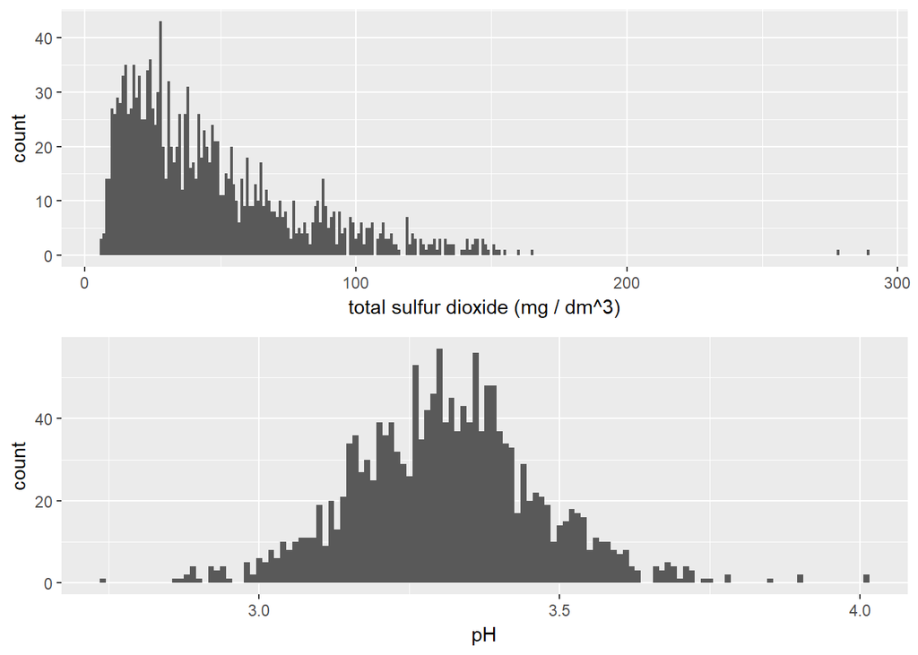

Another right skewed followed by a normal distribution.

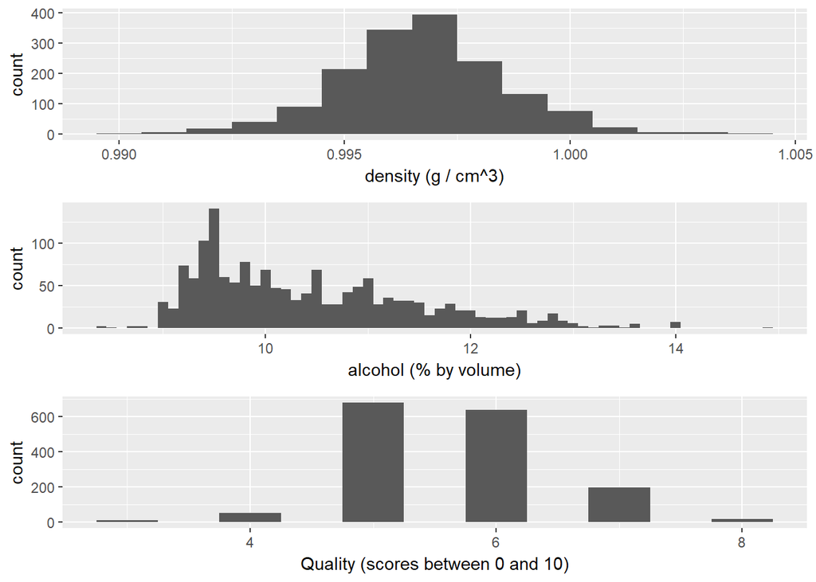

The quality is the only categorical variable.

# Univariate Analysis

### What is the structure of your dataset?

There are 1599 observation in 12 variables in this data set. Only the variable quality is a categorical variable (1 to 10, but this data set only has wines ranked between 3 and 8).

### What is/are the main feature(s) of interest in your dataset?

The most important feature is the quality. However, the data set has others variabels like de acids and the pH that maybe should be correlated with this output variable.

### Did you create any new variables from existing variables in the dataset?

No

### Of the features you investigated, were there any unusual distributions? Not that I found.

# Bivariate Plots Section

```
##  [1] "fixed.acidity"        "volatile.acidity"     "citric.acid"
##  [4] "residual.sugar"       "chlorides"            "free.sulfur.dioxide"
##  [7] "total.sulfur.dioxide" "density"              "pH"
## [10] "sulphates"            "alcohol"              "quality"
```

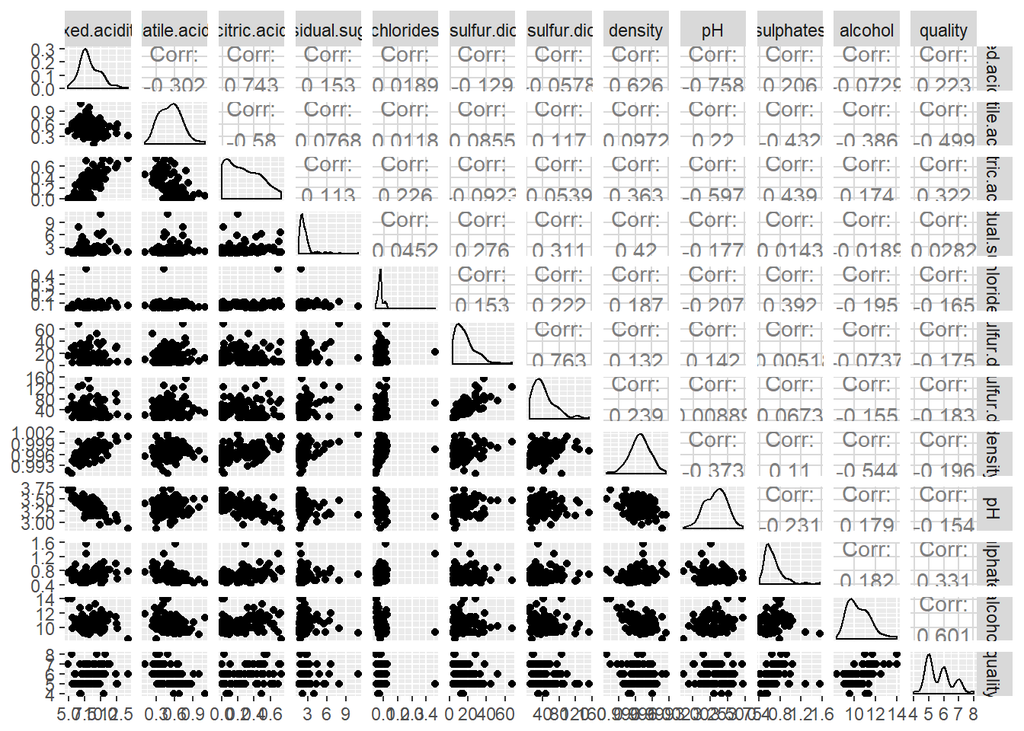

The pH variable tends to correlate with the acids (p. e fixed.acidity). The quality does not strongly correlate with the other variables, maybe a little with alcohol.

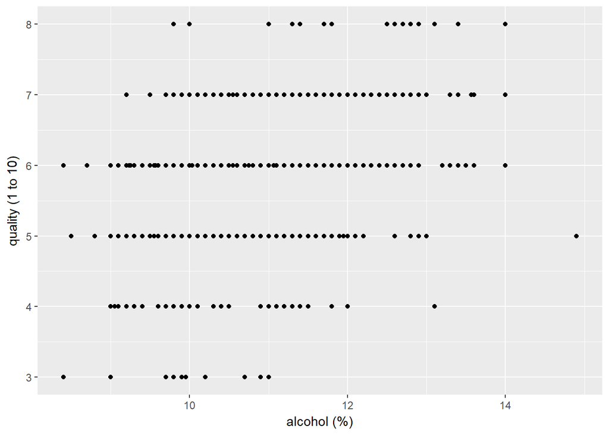

There is not too much to see here. The correlation does not show anything. The only thing is that the most wines received 5 or 6 for quality.

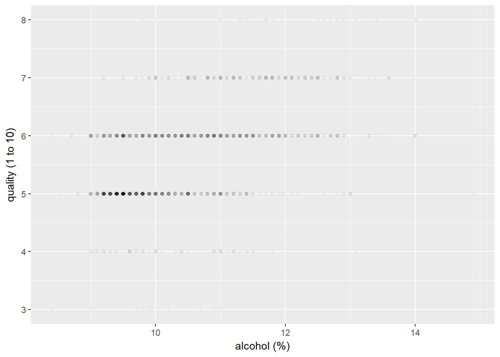

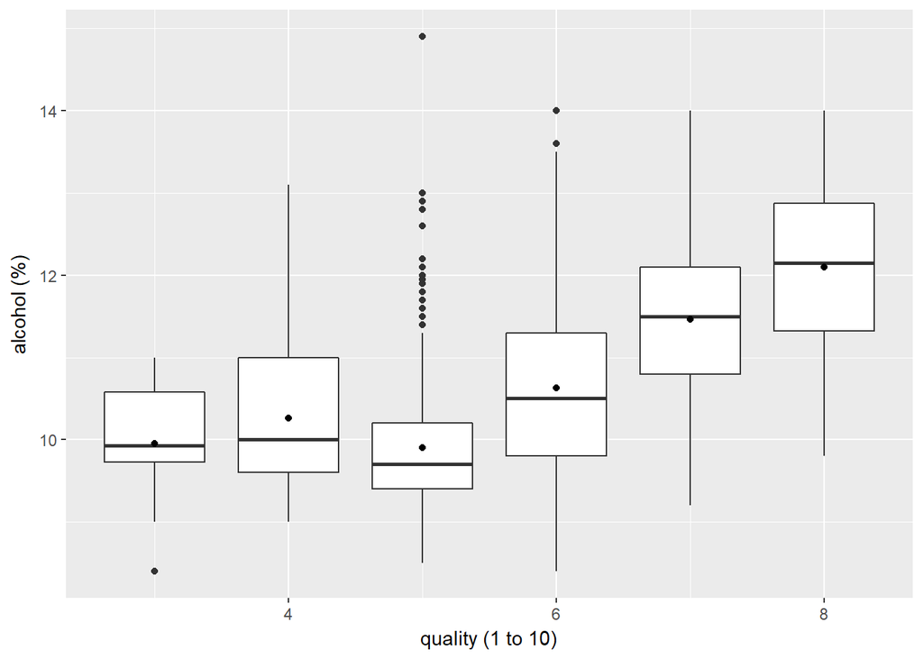

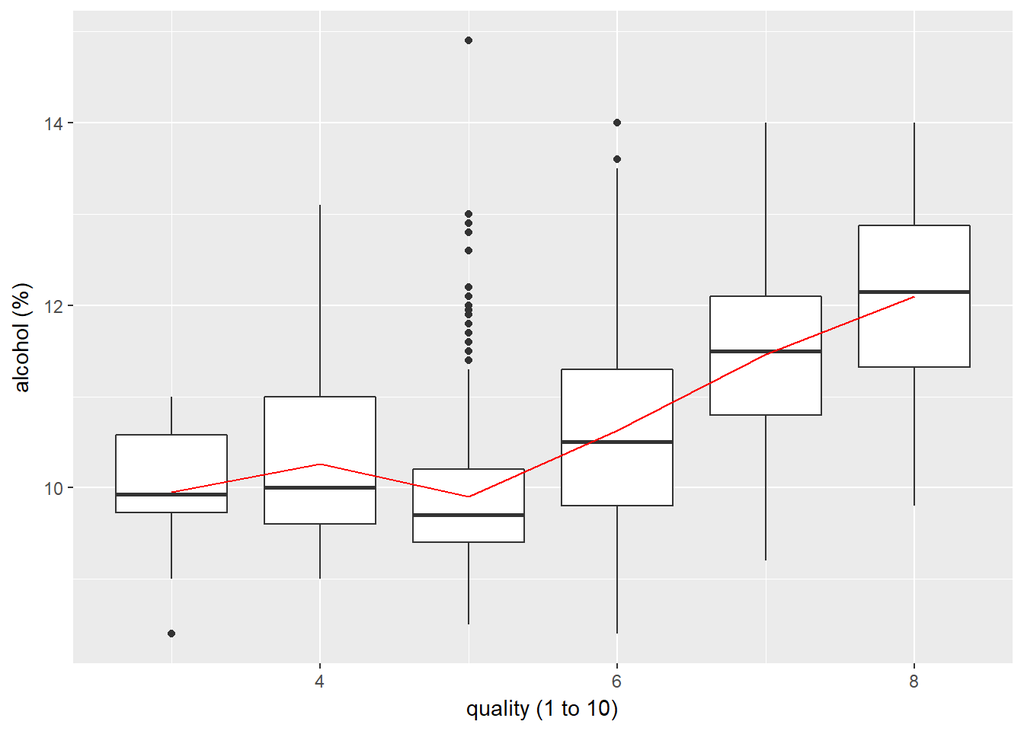

```
## ds$quality: 3
##    Min. 1st Qu.  Median    Mean 3rd Qu.    Max.
##   8.400   9.725   9.925   9.955  10.575  11.000
## --------------------------------------------------------
## ds$quality: 4
##    Min. 1st Qu.  Median    Mean 3rd Qu.    Max.
##    9.00    9.60   10.00   10.27   11.00   13.10
## --------------------------------------------------------
## ds$quality: 5
##    Min. 1st Qu.  Median    Mean 3rd Qu.    Max.
##     8.5     9.4     9.7     9.9    10.2    14.9
## --------------------------------------------------------
## ds$quality: 6
##    Min. 1st Qu.  Median    Mean 3rd Qu.    Max.
##    8.40    9.80   10.50   10.63   11.30   14.00
## --------------------------------------------------------
## ds$quality: 7
##    Min. 1st Qu.  Median    Mean 3rd Qu.    Max.
##    9.20   10.80   11.50   11.47   12.10   14.00
## --------------------------------------------------------
## ds$quality: 8
##    Min. 1st Qu.  Median    Mean 3rd Qu.    Max.
##    9.80   11.32   12.15   12.09   12.88   14.00
```

Here we can see something, the alcohol mean tends to be higher in the best wines.

```
## ds$quality: 3
##    Min. 1st Qu.  Median    Mean 3rd Qu.    Max.
##   3.160   3.312   3.390   3.398   3.495   3.630
## --------------------------------------------------------
## ds$quality: 4
##    Min. 1st Qu.  Median    Mean 3rd Qu.    Max.
##   2.740   3.300   3.370   3.382   3.500   3.900
## --------------------------------------------------------
## ds$quality: 5
##    Min. 1st Qu.  Median    Mean 3rd Qu.    Max.
##   2.880   3.200   3.300   3.305   3.400   3.740
## --------------------------------------------------------
## ds$quality: 6
##    Min. 1st Qu.  Median    Mean 3rd Qu.    Max.
##   2.860   3.220   3.320   3.318   3.410   4.010
## --------------------------------------------------------
## ds$quality: 7
##    Min. 1st Qu.  Median    Mean 3rd Qu.    Max.
##   2.920   3.200   3.280   3.291   3.380   3.780
## --------------------------------------------------------
## ds$quality: 8
##    Min. 1st Qu.  Median    Mean 3rd Qu.    Max.
##   2.880   3.163   3.230   3.267   3.350   3.720
```

```
## ds$quality: 3
##    Min. 1st Qu.  Median    Mean 3rd Qu.    Max.
##  0.9947  0.9961  0.9976  0.9975  0.9988  1.0008
## --------------------------------------------------------
## ds$quality: 4
##    Min. 1st Qu.  Median    Mean 3rd Qu.    Max.
##  0.9934  0.9957  0.9965  0.9965  0.9974  1.0010
## --------------------------------------------------------
## ds$quality: 5
##    Min. 1st Qu.  Median    Mean 3rd Qu.    Max.
##  0.9926  0.9962  0.9970  0.9971  0.9979  1.0031
## --------------------------------------------------------
## ds$quality: 6
##    Min. 1st Qu.  Median    Mean 3rd Qu.    Max.
##  0.9901  0.9954  0.9966  0.9966  0.9979  1.0037
## --------------------------------------------------------
## ds$quality: 7
##    Min. 1st Qu.  Median    Mean 3rd Qu.    Max.
##  0.9906  0.9948  0.9958  0.9961  0.9974  1.0032
## --------------------------------------------------------
## ds$quality: 8
##    Min. 1st Qu.  Median    Mean 3rd Qu.    Max.
##  0.9908  0.9942  0.9949  0.9952  0.9972  0.9988
```

```
## ds$quality: 3
##    Min. 1st Qu.  Median    Mean 3rd Qu.    Max.
##  0.4400  0.6475  0.8450  0.8845  1.0100  1.5800
## --------------------------------------------------------
## ds$quality: 4
##    Min. 1st Qu.  Median    Mean 3rd Qu.    Max.
##   0.230   0.530   0.670   0.694   0.870   1.130
## --------------------------------------------------------
## ds$quality: 5
##    Min. 1st Qu.  Median    Mean 3rd Qu.    Max.
##   0.180   0.460   0.580   0.577   0.670   1.330
## --------------------------------------------------------
## ds$quality: 6
##    Min. 1st Qu.  Median    Mean 3rd Qu.    Max.
##  0.1600  0.3800  0.4900  0.4975  0.6000  1.0400
## --------------------------------------------------------
## ds$quality: 7
##    Min. 1st Qu.  Median    Mean 3rd Qu.    Max.
##  0.1200  0.3000  0.3700  0.4039  0.4850  0.9150
## --------------------------------------------------------
## ds$quality: 8
##    Min. 1st Qu.  Median    Mean 3rd Qu.    Max.
##  0.2600  0.3350  0.3700  0.4233  0.4725  0.8500
```

```
## ds$quality: 3
##    Min. 1st Qu.  Median    Mean 3rd Qu.    Max.
##  0.0000  0.0050  0.0350  0.1710  0.3275  0.6600
## --------------------------------------------------------
## ds$quality: 4
##    Min. 1st Qu.  Median    Mean 3rd Qu.    Max.
##  0.0000  0.0300  0.0900  0.1742  0.2700  1.0000
## --------------------------------------------------------
## ds$quality: 5
##    Min. 1st Qu.  Median    Mean 3rd Qu.    Max.
##  0.0000  0.0900  0.2300  0.2437  0.3600  0.7900
## --------------------------------------------------------
## ds$quality: 6
##    Min. 1st Qu.  Median    Mean 3rd Qu.    Max.
##  0.0000  0.0900  0.2600  0.2738  0.4300  0.7800
## --------------------------------------------------------
## ds$quality: 7
##    Min. 1st Qu.  Median    Mean 3rd Qu.    Max.
##  0.0000  0.3050  0.4000  0.3752  0.4900  0.7600
## --------------------------------------------------------
## ds$quality: 8
##    Min. 1st Qu.  Median    Mean 3rd Qu.    Max.
##  0.0300  0.3025  0.4200  0.3911  0.5300  0.7200
```

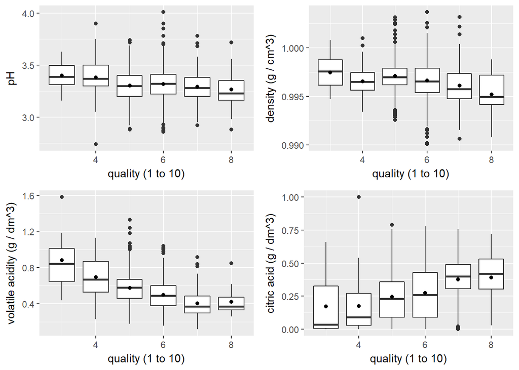

Now I tried the boxplot in other variables that could influentiate the tast and possibly the quality.

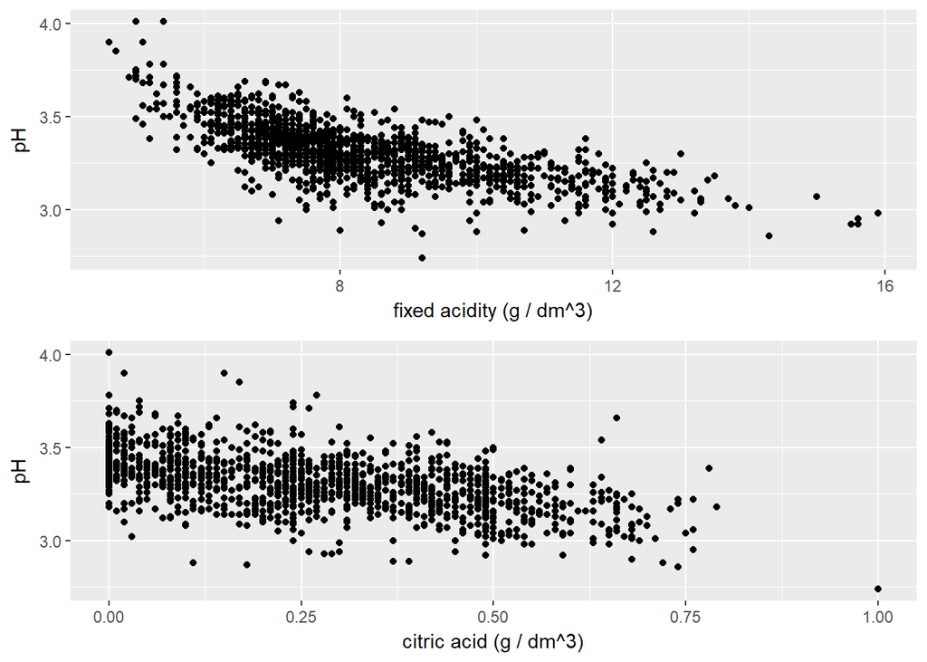

Looking to others variables. The correlation between pH and fixed.acidity suggest that greater the pH factor lesser the fixed.acidity. The same occurs with citric.acid.

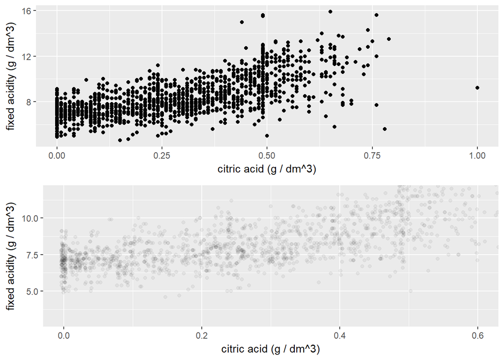

Here one of the strong correlations found in this data set.

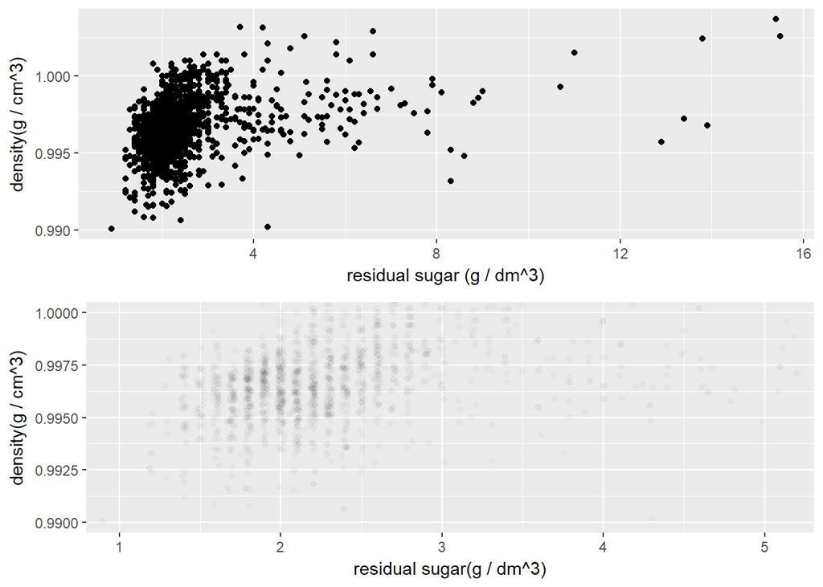

Now we have the residual.sugar against the destiny, there is some correlation between these two variable.

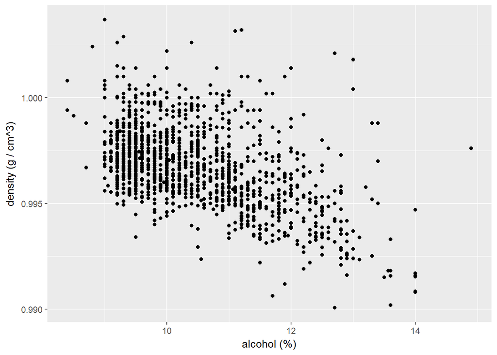

The last plot of Bivariate Analysis is density against alcohol.

# Bivariate Analysis

### Talk about some of the relationships you observed in this part of the investigation. How did the feature(s) of interest vary with other features in the dataset?

The data set has two main relationships of interest.

The first one is quality with some features that are related with taste, like the citric acid and alcohol. Here is the analyse plot by plot

- Quality vs Alcohol: as you can see in the plots, the best wines has more alcohol, the only exception is for wines graded 5 in quality.
- Quality vs pH and quality vs density: in general both (pH and Quality) tends to be lesser in better wines.
- Quality vs volatile acidity: this feature in high levels can lead to an unpleasant, vinegar taste, so as we can se in the plot the best wines tends to have lesser volatile acidity
- Quality vs citric acid: this acid is responsible for add some flavor to wines, so the best wines tends to have for of it.

The second group, I analysed the relantionships with other variables, and found that the pH has some correlation with fixed acidity and critic acid, that is because pH is related in the amount of acid in the wines. After that, we see how fixed acidity tends to be higher in more quantities of ciritc acid. The next analysis shows a correlation for density and residual sugar, it seems that residual sugar slightly influenciates density. FInally, I ploted how alcohol afects density, and its show that density decrease with more quantities of alcohol.

### Did you observe any interesting relationships between the other features

(not the main feature(s) of interest)?

Yes, pH has some correlation with fixed acidity and citric acid, as well as density and residual sugar and density and alcohol.

# Multivariate Plots Section

[figure not shown]

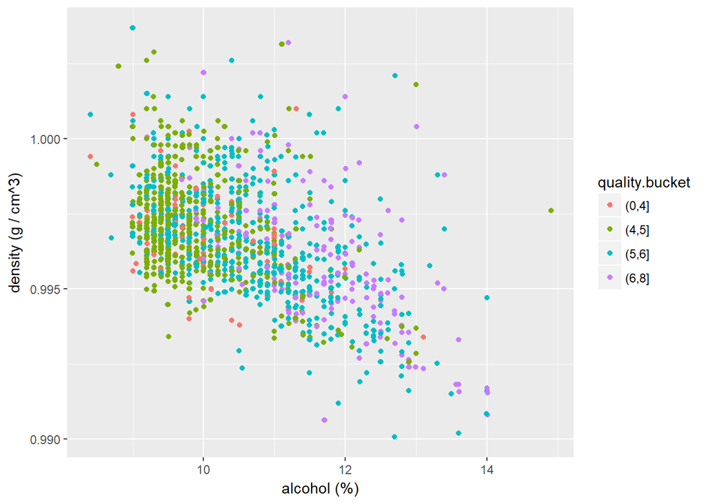

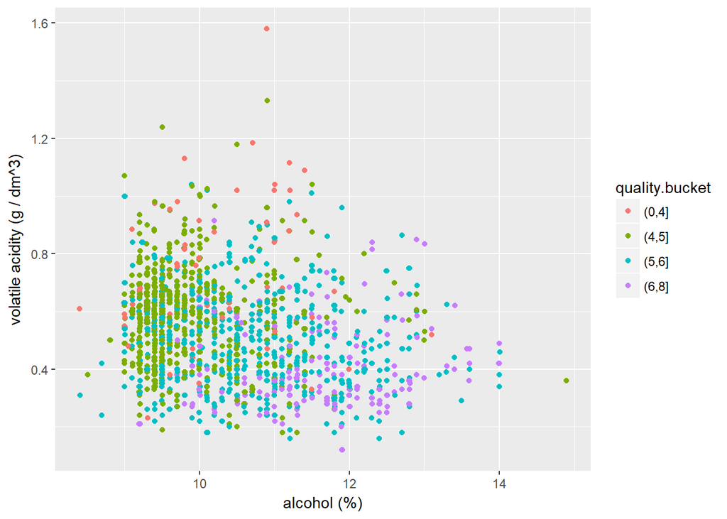

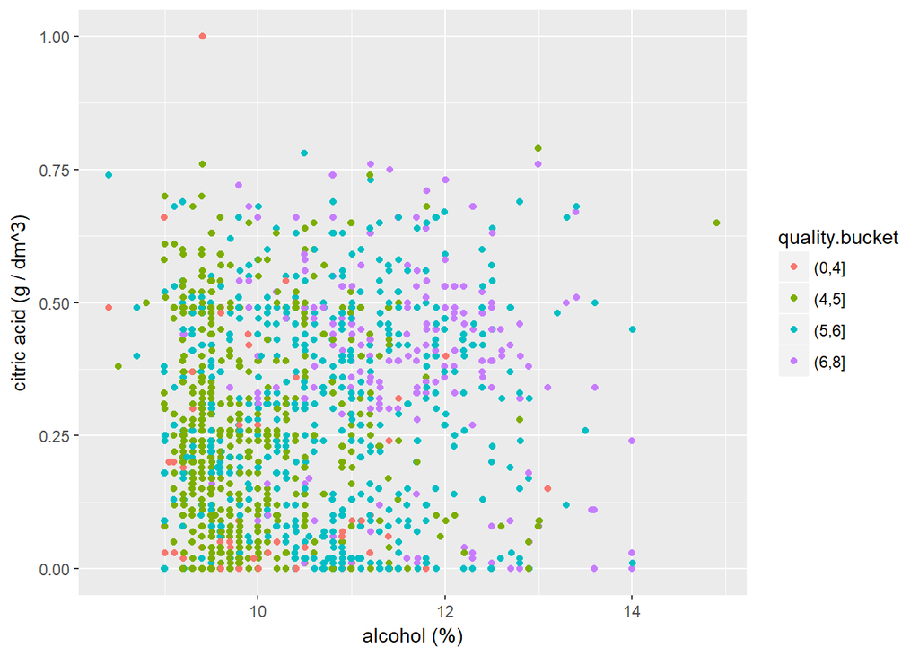

Since the correlation between quality and alcool are good, I dicided to plot this two features against other variables, like density and pH, to see the behavior and try to understand better why the quality scores.

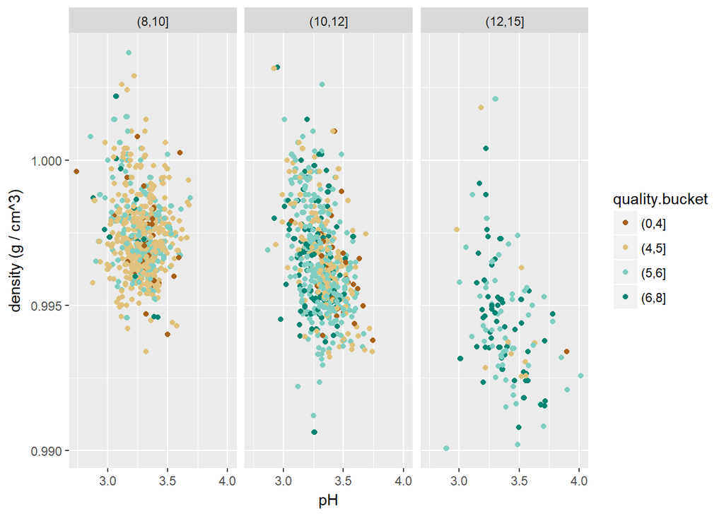

We knew that density and pH has some correlation with quality, here we can see better that.

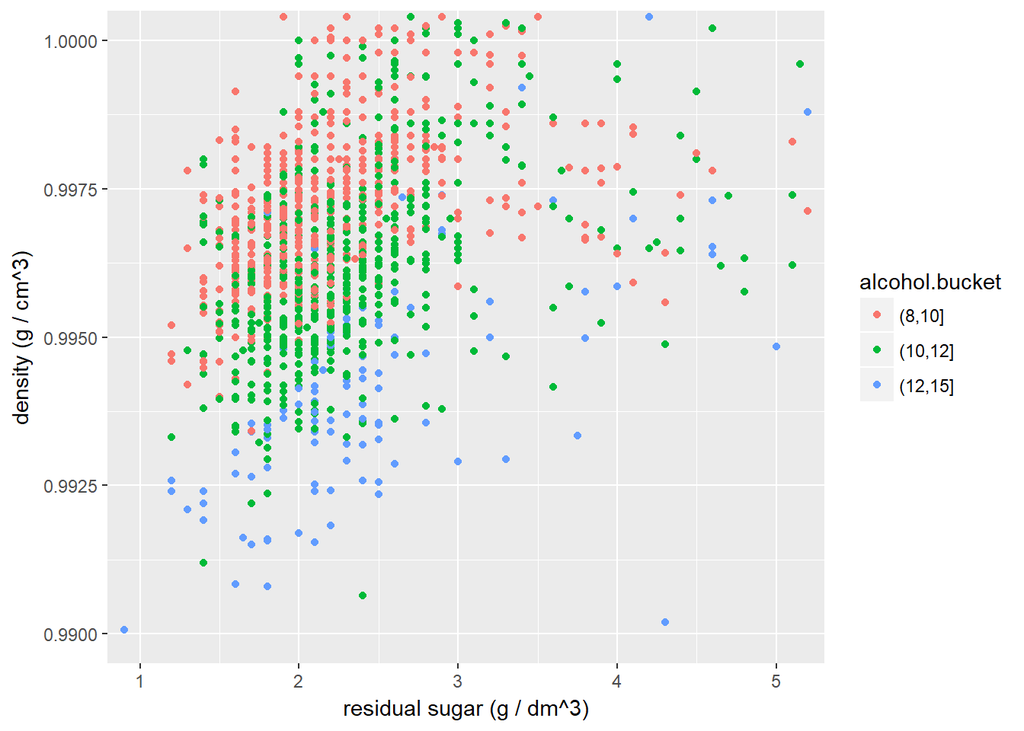

Since density depends on the percent of alcohol and sugar, here we plot these three together.

# Multivariate Analysis

### Talk about some of the relationships you observed in this part of the investigation. Were there features that strengthened each other in terms of looking at your feature(s) of interest?

The main feature of interest is quality, for obvious reasons. So, I observed that quality has some relation with alcohol and, in the first group of plots, I ploted these two with some other variable early observed and is reasonable to say that best wines tends to have less density and more alcohol.

### Were there any interesting or surprising interactions between features?

I thing quality and alcohol.

### OPTIONAL: Did you create any models with your dataset? Discuss the strengths and limitations of your model.

No, I did not.

# Final Plots and Summary

### Plot One

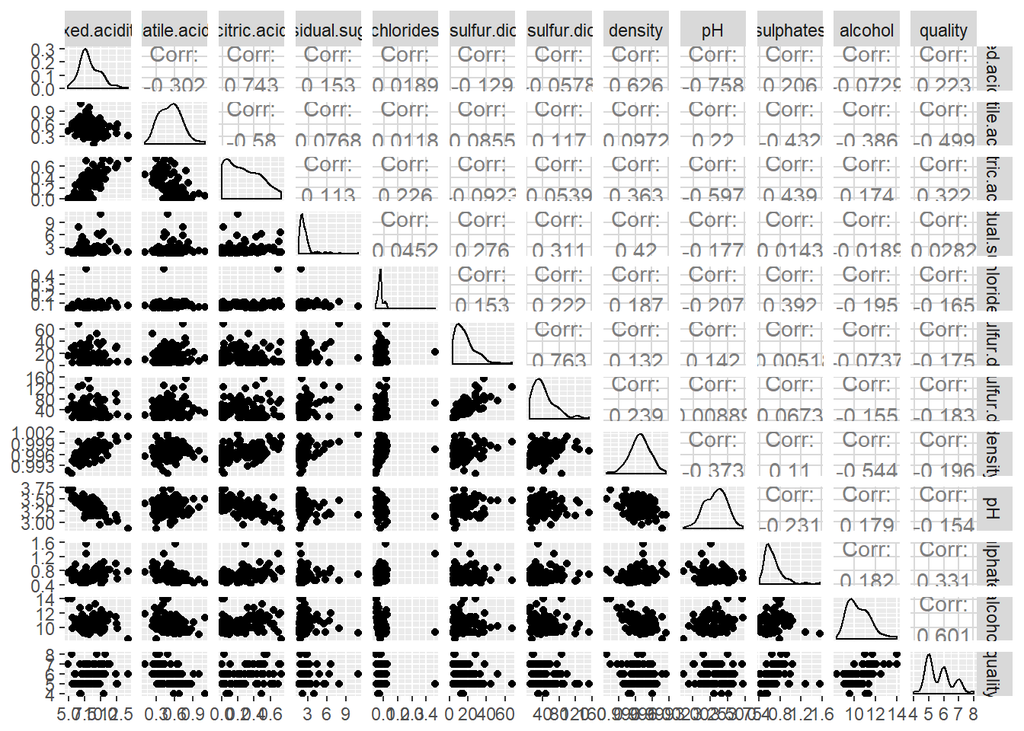

### Description One

For me this is one of the most significative plots, because we can see the data set as whole, and all the correlations.

### Plot Two

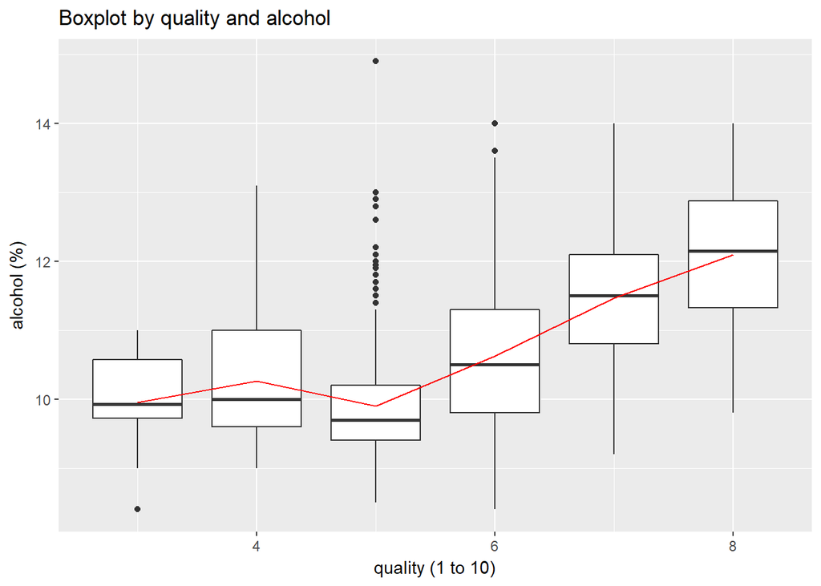

### Description Two

This is a good plot because you can see how the best wines ranked tends to have more alcohol.

### Plot Three

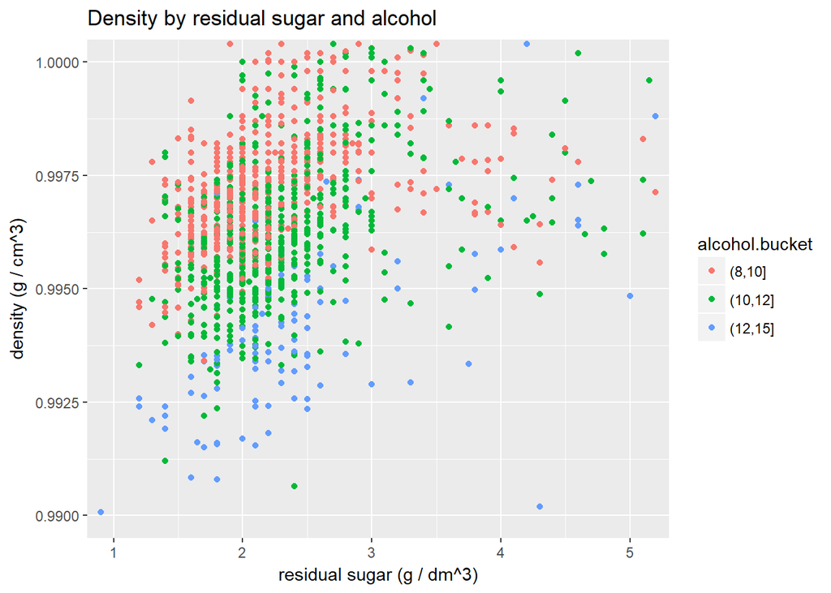

### Description Three

This is a good plot because its shows the correlation between other variables than the main one, quality. It shows in pratic what theory says, that density depends of the amount of residual sugar and alcohol.

# Reflection

The Red Wine dataset contains almost 1600 observation and has 11 attributes and one output variable(quality). First, I tried to understand each of the variables by looking the discription and make some research, then I plotted almost all variables in the univariate analisys.These plots shows two main behavior, the distributions was normals or right skeweds. The univariate analysis shows also that most wines was ranked with 5 ou 6 for quality.

The analysis became more interesting with Bivariate plots, where I found some correlations, like the amount of alcohol in wines that determine its quality. Other features that maybe determine the quality is some acids, like citric acids. In this part of the work I saw others features correlation, like how residual sugar and alcohol affects density.

For the last part of the analysis, Multivariate, I could not say that I found strong and meaningful relations, only the ones already showed in the previous analysis. Maybe that is because the limited amount of data (only 1599 observation), the poor correlation between the features (that is why I did not make a model) or the amount of permutation that I did not expore in depth.